# Numerical skills for neuroscience

Part 2 · Vectors, matrices and PCA

Matteo Lisi

## Linear algebra

| Tool | What it lets us do |
| --- | --- |
| **Vector** | Collect measurements into one object |
| **Matrix** | Organise data or combine measurements |
| **Projection** | Describe an observation along a chosen direction |
| **PCA** | Find directions that capture the most variation |

## A data matrix has rows and columns

[figure not shown]

$$\mathbf X\in\mathbb R^{n\times p}
\qquad n\text{ observations},\ p\text{ variables}$$

## A vector is a list and a point

[figure not shown]

$$\mathbf x=\begin{bmatrix}3\\2\end{bmatrix}$$

Two measurements → one point in **two dimensions**.

An arrow from the origin gives the same coordinates.

## Add vectors; multiply them by a scalar

[figure not shown]

$$\begin{bmatrix}1\\2\end{bmatrix}+\begin{bmatrix}3\\1\end{bmatrix}
=\begin{bmatrix}4\\3\end{bmatrix}
\qquad
2\begin{bmatrix}1.5\\1\end{bmatrix}=\begin{bmatrix}3\\2\end{bmatrix}$$

## A linear combination is a weighted sum

$$c\mathbf v+d\mathbf w
=c\begin{bmatrix}1\\1\end{bmatrix}
+d\begin{bmatrix}2\\3\end{bmatrix}
=\begin{bmatrix}c+2d\\c+3d\end{bmatrix}$$

$$2\mathbf v-\mathbf w=\begin{bmatrix}0\\-1\end{bmatrix}$$

## Span: everywhere those combinations can reach

[figure not shown]

A **basis** is an independent set that spans the space being described.

## A matrix packages the columns we want to combine

$$\mathbf A=
\begin{bmatrix}1&2\\1&3\end{bmatrix}
=\begin{bmatrix}\mathbf v&\mathbf w\end{bmatrix}$$

$$\underbrace{\mathbf A}_{2\times2}
\underbrace{\begin{bmatrix}c\\d\end{bmatrix}}_{2\times1}
=c\mathbf v+d\mathbf w$$

Matrix × vector = a weighted sum of the matrix’s **columns**.

## A dot product multiplies, then adds

$$\mathbf a^\mathsf T\mathbf b
=a_1b_1+a_2b_2+\cdots+a_pb_p$$

$$\begin{bmatrix}1&2\end{bmatrix}
\begin{bmatrix}3\\1\end{bmatrix}
=1\times3+2\times1=5$$

The result is **one number**.

## Dot products also describe alignment

[figure not shown]

$$\mathbf a^\mathsf T\mathbf b
=\|\mathbf a\|\,\|\mathbf b\|\cos\theta$$

In 2D: $\|\mathbf a\|=\sqrt{a_1^2+a_2^2}$. The angle requires **nonzero** vectors.

## Projection gives a coordinate along an axis

[figure not shown]

For a **unit** direction $\mathbf u$:

$$z=\mathbf x^\mathsf T\mathbf u$$

$$\text{projected vector}=z\mathbf u$$

One number locates the point along this line.

## Transpose swaps rows and columns

$$\mathbf A=
\begin{bmatrix}1&2&3\\4&5&6\end{bmatrix}
\qquad\Longrightarrow\qquad
\mathbf A^\mathsf T=
\begin{bmatrix}1&4\\2&5\\3&6\end{bmatrix}$$

$$2\times3\quad\longrightarrow\quad3\times2$$

In R: `t(A)`.

## Matrix multiplication: a row meets a column

[figure not shown]

## The same product, one column at a time

$$\mathbf A\mathbf B
=\begin{bmatrix}\mathbf A\mathbf b_1&\mathbf A\mathbf b_2\end{bmatrix}$$

$$\mathbf A\begin{bmatrix}2\\3\end{bmatrix}
=2\begin{bmatrix}1\\2\end{bmatrix}
+3\begin{bmatrix}1\\-1\end{bmatrix}
=\begin{bmatrix}5\\1\end{bmatrix}$$

Each column of the product is a combination of columns of $\mathbf A$.

## Check the dimensions before multiplying

$$\underbrace{\mathbf A}_{m\times n}
\underbrace{\mathbf B}_{n\times p}
=\underbrace{\mathbf C}_{m\times p}$$

**$100\times2$**. Reversed: inner dimensions $2$ and $100$ do not match.

## In R, `*` and `%*%` do different jobs

**Element by element**

```r
A <- matrix(c(1, 1, 2, -1), 2, byrow = TRUE)
B <- matrix(c(2, 2, 3, 4), 2, byrow = TRUE)
A * B
```

```
     [,1] [,2]
[1,]    2    2
[2,]    6   -4
```

**Matrix multiplication**

```r
A %*% B
```

```
     [,1] [,2]
[1,]    5    6
[2,]    1    0
```

Rows meet columns; products are added.

## A matrix can transform a whole space

$$\mathbf S=\begin{bmatrix}2&0\\0&1\end{bmatrix}
\qquad\mathbf S\begin{bmatrix}x_1\\x_2\end{bmatrix}
=\begin{bmatrix}2x_1\\x_2\end{bmatrix}$$

[figure not shown]

## Eigenvectors keep the same line of action

$$\mathbf S\mathbf v=\lambda\mathbf v,\qquad\mathbf v\ne\mathbf0$$

[figure not shown]

Teal: input. Orange: transformed vector. $\lambda$ is the eigenvalue.

## PCA: which direction keeps the most variation?

[figure not shown]

**PC1:** largest variance of projected scores.

**PC2:** largest remaining variance, perpendicular to PC1.

## Step 1: centre each variable

[figure not shown]

$$X_{c,ij}=X_{ij}-\overline X_j$$

## Step 2: summarise how centred variables vary together

[figure not shown]

$$\mathbf S=\frac{\mathbf X_c^\mathsf T\mathbf X_c}{n-1}$$

$$\begin{bmatrix}
\operatorname{Var}(x_1)&\operatorname{Cov}(x_1,x_2)\\
\operatorname{Cov}(x_1,x_2)&\operatorname{Var}(x_2)
\end{bmatrix}$$

Diagonal: spread.  
Off diagonal: variation together.

## Step 3: directions and amounts of variation

$$\mathbf S\mathbf v_j=\lambda_j\mathbf v_j$$

| PCA object | What it represents |
| --- | --- |
| Eigenvector $\mathbf v_j$ | A unit direction: the **loading vector** |
| Eigenvalue $\lambda_j$ | Variance of scores along that direction |
| Largest eigenvalue | The first principal component direction |

## R: build the example and find the directions

```r
# simulate correlated data
n <- 250
x1 <- rnorm(n)
x2 <- x1 + rnorm(n)
X <- cbind(x1 + 5, x2 + 10)

# center the variables
Xc <- X
for (j in 1:ncol(X)){
  Xc[, j] <- X[, j] - mean(X[, j])
}

# compute variance-covariance matrix
S <- t(Xc) %*% Xc / (n - 1)

# computes eigenvalues and eigenvector
decomposition <- eigen(S, symmetric = TRUE)
V <- decomposition$vectors
lambda <- decomposition$values
```

Complete, commented example: pca_example.R

## Step 4: scores are the new coordinates

$$\underbrace{\mathbf Z}_{n\times p}
=\underbrace{\mathbf X_c}_{n\times p}
\underbrace{\mathbf V}_{p\times p}$$

[figure not shown]

## How much variation does each component retain?

[figure not shown]

$$\text{fraction for PC }j=\frac{\lambda_j}{\sum_k\lambda_k}$$

PC1 retains **86.8%** here.

## Step 5: keep one score and reconstruct an approximation

[figure not shown]

$$\widehat{\mathbf x}_c=z_1\mathbf v_1$$

One coordinate gives a point on a line.

Add the means back to recover the original units and location.

## R: project, measure retained variance, reconstruct

```r
# compute scores (coordinates along PC axes)
scores <- Xc %*% V

# variance explained by each PC
lambda <- decomposition$values
variance_fraction <- lambda / sum(lambda)

# select first PC scores
z1 <- scores[, 1, drop = FALSE]
v1 <- V[, 1, drop = FALSE] # 1st eigenvector

# keep 1PC and do approximate reconstruction
Xc_approx <- z1 %*% t(v1)
X_approx <- Xc_approx
for (j in 1:ncol(X)) {
  X_approx[, j] <- Xc_approx[, j] + mean(X[, j])
}
```

## Which changes should affect PCA?

**A:** centring removes it. **B:** generally changes covariance PCA.  
**C:** same axis and reconstruction; opposite signs.

## PCA in a paper: a trajectory through neural population activity

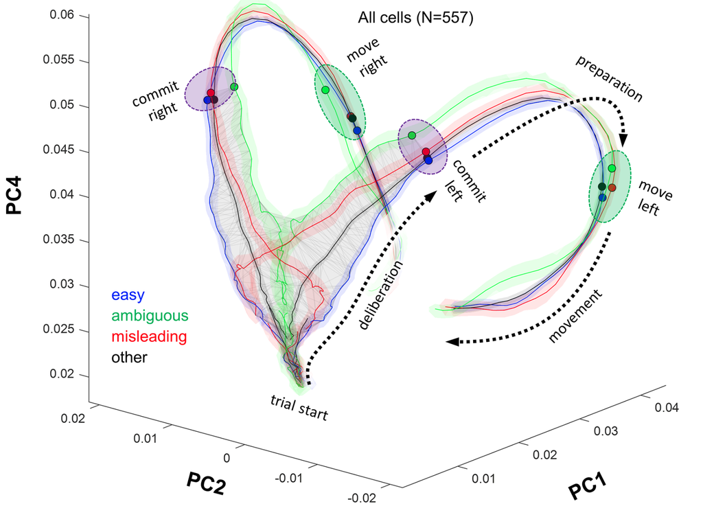

**Figure 4A**

Each location = population activity at a time point.

PC axes = weighted combinations of neural responses.

The line links successive states.

Thura, Cabana, Feghaly & Cisek (2022), *PLOS Biology*, Figure 4A. [doi:10.1371/journal.pbio.3001861](https://doi.org/10.1371/journal.pbio.3001861).

## Part 2 summary

**Vectors** represent points/directions in space; **matrices** can be seen as functions that transform them.

**Linear combinations** of vectors can create new vectors from old ones; **span** is the space of possible combinations; **linear (in)dependence** tells us when vector carry redundant information.

**Matrix–vector multiplication** is a linear combination of the matrix columns; **dot products** connect algebra and geometry (gives angular distances between vector orientations); and **matrix multiplication** can be seens as “combination of combinations” of columns or a sequence of dot products.

**Eigenvectors** are vectors which are fixed in direction under a given linear transformation (a matrix); the scaling factor of these eigenvectors is then called the **eigenvalue**. (Roughly the eigenvalue is a measure of the distortion induced by the transformation and the eigenvectors tell you about how the distortion is oriented.)

**PCA** uses eigen-decomposition to find directions of maximal variance for constructing a simpler, interpretable representations.

## Read the mathematics in a paper

| See this… | Read it as… |
| --- | --- |
| $\mathbf A\mathbf x$ | A combination of columns; a transformation |
| $\mathbf a^\mathsf T\mathbf b$ | Multiply corresponding entries, then add |
| $\mathbf S\mathbf v=\lambda\mathbf v$ | A special direction and its scale factor |
| $\mathbf Z=\mathbf X_c\mathbf V$ | Centred observations in new coordinates |

## Identity and inverse: leave unchanged, or undo

$$\mathbf I=\begin{bmatrix}1&0\\0&1\end{bmatrix}
\qquad\mathbf I\mathbf x=\mathbf x$$

$$\mathbf S^{-1}=\begin{bmatrix}1/2&0\\0&1\end{bmatrix}
\qquad\mathbf S^{-1}\mathbf S=\mathbf I$$

An ordinary inverse exists only for a **square, full-rank** matrix.

## A linear model is a matrix-vector product

$$\widehat{\mathbf y}
=\underbrace{\begin{bmatrix}1&0\\1&1\\1&2\end{bmatrix}}_{\mathbf X}
\underbrace{\begin{bmatrix}5\\2\end{bmatrix}}_{\boldsymbol\beta}
=\begin{bmatrix}5\\7\\9\end{bmatrix}$$

$$\mathbf y=\mathbf X\boldsymbol\beta+\boldsymbol\varepsilon$$

Rows = observations. Columns = intercept and predictor. Weights = coefficients.

## A network layer combines inputs using weights

[figure not shown]

$$\underbrace{\mathbf z}_{2\times1}
=\underbrace{\mathbf W}_{2\times3}
\underbrace{\mathbf x}_{3\times1}
+\underbrace{\mathbf b}_{2\times1}$$

$$\mathbf y=g(\mathbf z)$$

Weights → sums → activation.

## Scaling changes the question PCA answers

[figure not shown]

Centring removes offsets. **Standardising** also divides by each variable’s SD.

PS5210 · Numerical skills for neuroscience